# FOOD GROUPS AND RHEUMATOID ARTHRITIS

## A CHECK ON CLUSTERING THE FACTORS (KMEDOIDS)

```r
library(RColorBrewer)

data_scaled_with_factor_cores <- cbind(data[,1],data_scaled, factor_scores)

# Select columns for clustering (Factor1 to Factor16)
data_for_clustering <- data_scaled_with_factor_cores[, paste0("Factor", 1:16)]

dist_matrix <- dist(data_for_clustering, method = "euclidean")

# Perform K-Medoids clustering
k <- 2  # Number of clusters
pam_result <- pam(dist_matrix, k = k)


# Print clustering results
print(pam_result)
```

```
## Medoids:
##      ID
## [1,] 44 44
## [2,] 59 59
## Clustering vector:
##   [1] 1 2 2 1 1 1 2 1 2 2 1 1 1 2 1 2 2 2 2 1 1 2 2 1 2 2 2 1 1 1 1 1 2 2 2 2 2
##  [38] 2 1 1 1 2 2 1 1 2 2 1 1 2 1 2 1 1 1 2 1 1 2 2 2 1 2 1 1 1 1 1 1 1 2 2 2 2
##  [75] 2 1 1 2 1 2 2 2 2 1 1 1 1 2 1 1 2 2 1 2 1 2 2 1 1 1 1 1 2 2 2 1 1 1 2 1 1
## [112] 1 2 1 1 1 2 2 1 1 2 1 1 2 1 1 2 1 2 2 2 1 2 1 2 1 2 2 1 2 1 2 1 2 1 1 1 1
## [149] 1 2 1 1 2 1 2 2 2 2 2 1 2 1 2 2 2 1 2 2 1 2 1 1 1 1 2 2 2 2 1 1 2 2 1 1 1
## [186] 1 2 2 1 1 1 2 2 1 1 1 1 1 1 1 2 1 1 2 2 2 2 1 1 2 1 1 2 2 2 2 1 1 2 2 1 2
## [223] 2 2 2 2 1 1 2 1 2 1 2 1 2 2 1 1 2 1 2 2 2 2 2 1 1 2 1 1 2 2 2 2 2 1 2 1 1
## [260] 1 1 1 2 1 1 1 2 1 2 2 1 1 1 1 2 1 2 1 2 2 2 2 1 2 2 2 1 2 1 1 2 2 2 2 1 1
## [297] 2 1 2 2 1 1 1 2 1 2 1 2 2 2 1 1 2 1 1 1 2 1 2 2 2 2 2 1 2 2 2 2 1 1 2 1 1
## [334] 1 1 2 1 2 1 1 2 2 1 1 1 2 2 2 2 1 1 2 2 2 1 1 1 2 1 1 2 1 2 2 2
## Objective function:
##    build     swap
## 3.486932 3.486932
##
## Available components:
## [1] "medoids"    "id.med"     "clustering" "objective"  "isolation"
## [6] "clusinfo"   "silinfo"    "diss"       "call"
```

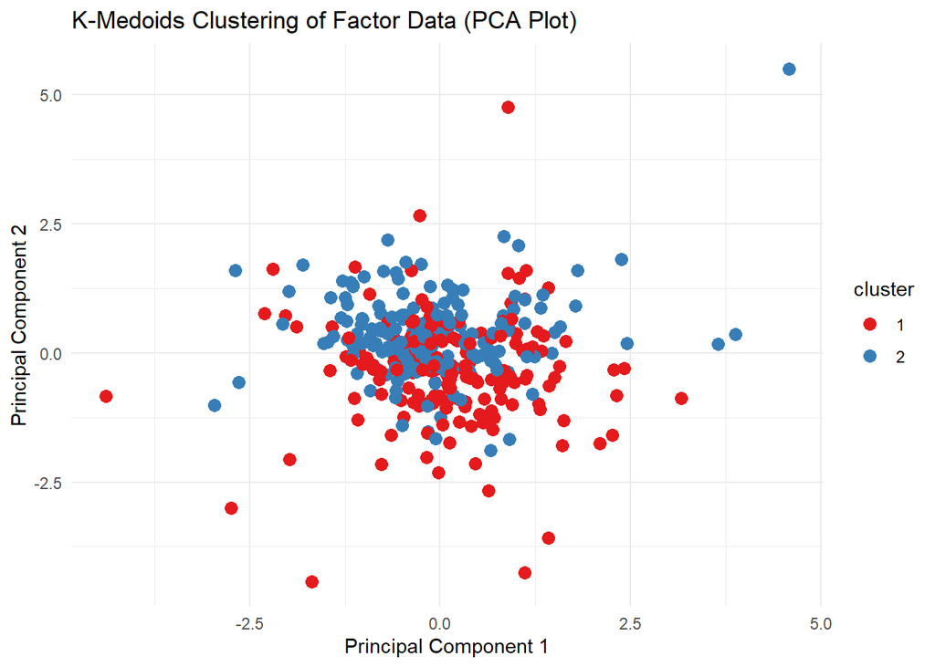

```r
# Extract cluster membership
cluster_membership <- pam_result$clustering

# Perform PCA for visualization
pca_result <- prcomp(data_for_clustering, scale. = TRUE)  # Scale for PCA

# Create PCA plot colored by clusters
pca_df <- as.data.frame(pca_result$x[, 1:2])  # Use first two principal components
pca_df$cluster <- factor(cluster_membership)

# Plot using ggplot2
ggplot(pca_df, aes(PC1, PC2, color = cluster)) +
  geom_point(size = 3) +
  scale_color_brewer(palette = "Set1") +
  labs(title = "K-Medoids Clustering of Factor Data (PCA Plot)",
       x = "Principal Component 1",
       y = "Principal Component 2") +
  theme_minimal()
```

#### Here we see that the patients are more or less uniformly distributed in the 2 groups, which can’t be clustered using the K-Medoids Clustering.

```r
# Set seed for reproducibility
set.seed(1)

# Perform k-means clustering with k = 2 clusters
#str(df1_scaled_with_factor_scores)
kmeans_data_for_clustering <- data_scaled_with_factor_cores[, paste0("Factor", 1:16)] # Factors data

# str(kmeans_data_for_clustering)

km <- kmeans(kmeans_data_for_clustering, centers = 2, nstart = 15) # Performing K-means

# Print the clustering results
# print(km)

# Attach the cluster assignments to your original data
data_with_clusters_kmeans <- cbind(kmeans_data_for_clustering, cluster = km$cluster)
print(data_with_clusters_kmeans)
```

```
##          Factor1      Factor2       Factor3      Factor4       Factor5
## 1   -0.444173860 -0.579839986  0.1543385592  0.363285373 -0.3692406716
## 2   -0.388753506  3.806360508  0.3170180505 -0.479298495 -0.6692591797
## 3    0.285029799 -1.512265182  0.4883264747  1.580639337 -1.1332455587
## 4   -0.160686218 -1.033867840  0.1062589045 -0.941050210  0.2697141899
## 5   -0.306496741  0.394061898 -0.1586754959 -0.465991519 -0.3005891047
## 6   -0.775497365  0.770017377  0.0265326554 -0.368554784  0.0704912835
## 7   -0.457240334 -0.567809911  0.3488155694 -0.857157082  2.4032928457
## 8    0.473092213  2.079265376  0.0344623005  0.663696581  0.2136540183
## 9   -0.166864405  0.252688909  0.4780350770 -0.292271961  0.7658964919
## 10  -0.762696752 -0.605531920 -0.1234820377 -0.098186759 -0.9822924989
## 11   0.771008830  0.285397784 -0.4760004323  0.119357731 -0.3342575632
## 12  -0.445814273  0.359535590 -0.2584955398 -0.472018706  0.7434900375
## 13  -0.203947188  2.000639449 -0.3086740794 -1.047911076  0.3745371733
## 14  -0.203432198 -0.834639701  1.0460879087  0.251655846 -1.7748272774
```

[output cut: 1449 more lines]

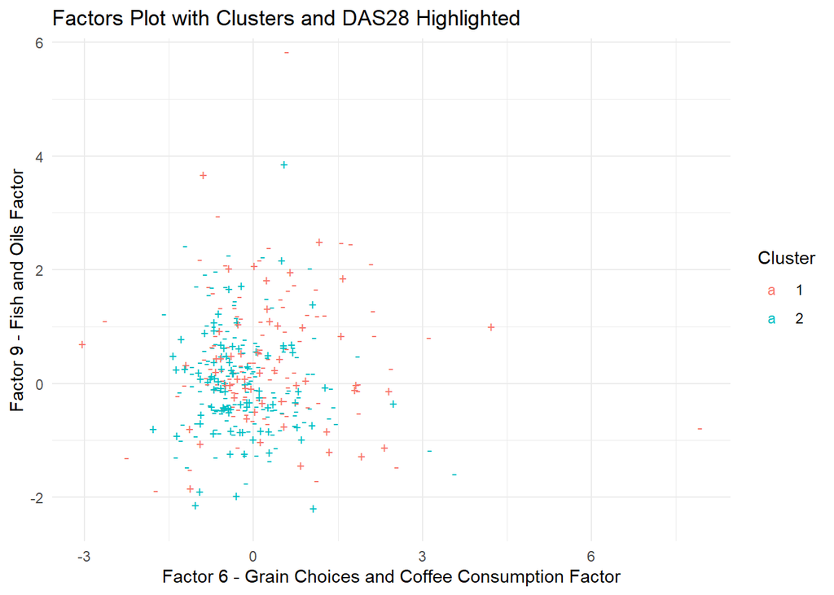

```r
das28_data <- data[, c("code", "DAS28")]

combined_data_km <- merge(data_scaled_with_factor_cores, das28_data, by = "code")
combined_data_km <- cbind(combined_data_km, cluster = km$cluster)

# Define the labels for points based on DAS28 values
combined_data_km$DAS28_label <- ifelse(combined_data_km$DAS28 < 2.6, "-", "+")

##Graph
ggplot(combined_data_km, aes(x = Factor6, y = Factor9, color = factor(cluster), label = DAS28_label)) +
  geom_text(vjust = -0.5, hjust = 0.5, size = 3) +
  labs(title = "Factors Plot with Clusters and DAS28 Highlighted",
       x = "Factor 6 - Grain Choices and Coffee Consumption Factor",
       y = "Factor 9 - Fish and Oils Factor",
       color = "Cluster") +
  scale_color_discrete(name = "Cluster") +
  theme_minimal()
```

```r
# Calculate percentages for each cluster
percentage_summary <- combined_data_km %>%
  group_by(cluster) %>%
  summarise(DAS28_Remission_percentage = mean(DAS28 < 2.6) * 100,
            DAS28_Active_percentage = mean(DAS28 >= 2.6) * 100)

# Round percentages to 1 decimal place
percentage_summary <- percentage_summary %>%
  mutate(across(starts_with("percent"), ~ round(., 1)))

# Print tabular output
print(percentage_summary)
```

```
## # A tibble: 2 × 3
##   cluster DAS28_Remission_percentage DAS28_Active_percentage
##     <int>                      <dbl>                   <dbl>
## 1       1                       64.7                    35.3
## 2       2                       60.5                    39.5
```

#### Here we see that the patients are more or less uniformly distributed in the groups, which can’t be clustered using the K-Means.

## FINDING CONFOUNDING FACTORS

```r
conf_indices = c(2, 12, 13, 97:99, 101, 104:105,119,123, 126, 128, 130:132 , 135, 137:143, 145:177, 181:182, 189, 224:226, 229, 124) #Counfounders selected

df_convar <- data.frame(data[,conf_indices])

df_convar[] <- lapply(df_convar, function(x) if(is.character(x)) as.factor(x) else x)

summary(df_convar)
```

```
##     Water_g         Alcohol_g       Energy_kcal       Visit_Age
##  Min.   : 207.9   Min.   : 0.000   Min.   : 380.4   Min.   :21.40
##  1st Qu.: 988.1   1st Qu.: 0.000   1st Qu.:1512.4   1st Qu.:47.81
##  Median :1346.7   Median : 1.716   Median :1975.8   Median :58.46
##  Mean   :1477.8   Mean   : 6.695   Mean   :2069.4   Mean   :57.51
##  3rd Qu.:1776.4   3rd Qu.: 8.903   3rd Qu.:2454.2   3rd Qu.:69.03
##  Max.   :6934.6   Max.   :55.440   Max.   :6142.8   Max.   :90.70
##
##  Disease_Duration      Sex           Education        BMI
##  Min.   : 0.55    Femmina:287   elementari: 49   Min.   :14.79
##  1st Qu.: 8.08    Maschio: 78   medie     : 79   1st Qu.:21.00
##  Median :12.81                  superiori :134   Median :23.63
##  Mean   :15.65                  università: 87   Mean   :24.29
##  3rd Qu.:20.72                  NA's      : 16   3rd Qu.:26.78
##  Max.   :57.01                                   Max.   :42.06
##
##        RF           ESR_mm_h        GH_PATIENT        GERD     Gastritis
##  Min.   :0.000   Min.   :  0.00   Min.   :  0.00   FALSO:295   FALSO:333
##  1st Qu.:0.000   1st Qu.:  6.00   1st Qu.: 60.00   VERO : 70   VERO : 32
##  Median :1.000   Median : 12.00   Median : 70.00
##  Mean   :0.537   Mean   : 16.98   Mean   : 69.84
##  3rd Qu.:1.000   3rd Qu.: 22.25   3rd Qu.: 85.00
##  Max.   :1.000   Max.   :104.00   Max.   :100.00
##                  NA's   :165
##  Hypertension     DM      Cardiopathy  Steroids     Nsaids       MTX
##  FALSO:243    FALSO:346   FALSO:346   FALSO:209   FALSO:305   FALSO:196
##  VERO :122    VERO : 19   VERO : 19   VERO :156   VERO : 60   VERO :169
##
##
##
##
##
##     SSZ         LFN         HCQ      Gold_Salts     CYA       csDMARDS
##  FALSO:359   FALSO:342   FALSO:258   FALSO:364   FALSO:363   FALSO:118
##  VERO :  6   VERO : 23   VERO :107   VERO :  1   VERO :  2   VERO :247
##
##
##
##
##
```

[output cut: 49 more lines]

```
##  Ex-fumatore :118   FALSO:306             FALSO:315
##  Fumatore    : 55   VERO : 59             VERO : 50
##  Non fumatore:189
##  NA's        :  3
##
##
##
##  Fruit_Vegetable_Disinfectants  Animals        DAS28
##  FALSO:335                     FALSO:323   Min.   :0.960
##  VERO : 30                     VERO : 42   1st Qu.:1.611
##                                            Median :2.213
##                                            Mean   :2.465
##                                            3rd Qu.:3.023
##                                            Max.   :7.971
##
```

```r
n=nrow(data_selected)
m=ncol(data_selected)
n
```

```
## [1] 365
```

```r
m
```

```
## [1] 33
```

## STANDARDIZING 1, 0, TRUE, FALSE FOR DIFFERENT VARIABLES

```r
# Function to convert columns to "VERO" or "FALSO"
convert_to_vero_falso <- function(df, columns) {
  for (col in columns) {
    df[[col]] <- as.character(df[[col]])
    df[[col]][df[[col]] == "1"] <- "VERO"
    df[[col]][df[[col]] == "0"] <- "FALSO"
    df[[col]] <- as.factor(df[[col]])
  }
  return(df)
}

# Define columns to standardize
columns_to_standardize <- c("Past_ETN",
                            "Past_ADA",
                            "Past_GOL",
                            "Past_IFX",
                            "Past_CER",
                            "Past_TCZ",
                            "Past_ABT",
                            "Past_RTX",
                            "Past_Anakinra")

# Apply conversion function
df_convar <- convert_to_vero_falso(df_convar, columns_to_standardize)

# Print column names to verify
print(names(df_convar))
```

```
##  [1] "Water_g"                       "Alcohol_g"
##  [3] "Energy_kcal"                   "Visit_Age"
##  [5] "Disease_Duration"              "Sex"
##  [7] "Education"                     "BMI"
##  [9] "RF"                            "ESR_mm_h"
## [11] "GH_PATIENT"                    "GERD"
## [13] "Gastritis"                     "Hypertension"
## [15] "DM"                            "Cardiopathy"
## [17] "Steroids"                      "Nsaids"
## [19] "MTX"                           "SSZ"
## [21] "LFN"                           "HCQ"
## [23] "Gold_Salts"                    "CYA"
## [25] "csDMARDS"                      "bDMARDs"
## [27] "TP_CLASSIFICATION"             "Numbiologicals"
## [29] "anti.TNF"                      "anti.IL6"
```

[output cut: 18 more lines]

```r
print(df_convar)
```

```
##       Water_g Alcohol_g Energy_kcal Visit_Age Disease_Duration     Sex
## 1    842.9903  15.97312   2036.9331     40.59             7.61 Maschio
## 2   2869.7719   0.99240   2466.4020     37.38            11.64 Femmina
## 3    947.2093   8.07662   1778.8344     40.36             8.61 Femmina
## 4   1133.7767   0.95808   1785.6769     50.41            29.62 Femmina
## 5   1551.9202   7.99050   1694.3492     67.70            13.18 Femmina
## 6   1643.8107   7.38990   2508.2278     39.17            11.03 Femmina
## 7    844.4831   0.00000   1389.6150     70.07            26.04 Femmina
## 8   2490.4595   0.61568   2439.3938     58.40            35.63 Femmina
## 9   1246.7022   2.33714   1908.0003     40.45            19.62 Femmina
## 10  1350.1599  31.71490   2027.0087     55.39             6.11 Maschio
## 11  1413.0817  11.76218   2926.4973     37.50            15.62 Femmina
## 12  1645.4118   8.90322   2314.1501     57.36            15.62 Femmina
## 13  1812.0533   0.61568   2367.5902     55.23            15.62 Femmina
## 14  1043.5072  55.43972   1599.5345     51.13             9.62 Maschio
```

[output cut: 3645 more lines]

```r
str(df_convar)
```

```
## 'data.frame':    365 obs. of  65 variables:
##  $ Water_g                      : num  843 2870 947 1134 1552 ...
##  $ Alcohol_g                    : num  15.973 0.992 8.077 0.958 7.99 ...
##  $ Energy_kcal                  : num  2037 2466 1779 1786 1694 ...
##  $ Visit_Age                    : num  40.6 37.4 40.4 50.4 67.7 ...
##  $ Disease_Duration             : num  7.61 11.64 8.61 29.62 13.18 ...
##  $ Sex                          : Factor w/ 2 levels "Femmina","Maschio": 2 1 1 1 1 1 1 1 1 2 ...
##  $ Education                    : Factor w/ 4 levels "elementari","medie",..: 3 4 2 3 4 3 1 2 3 2 ...
##  $ BMI                          : num  26.3 21.6 20.1 25.1 30.9 ...
##  $ RF                           : num  1 0 1 0 1 0 0 0 0 0 ...
##  $ ESR_mm_h                     : num  4 NA 24 20 NA 12 NA 4 46 20 ...
##  $ GH_PATIENT                   : num  75 95 90 40 85 100 50 70 50 30 ...
##  $ GERD                         : Factor w/ 2 levels "FALSO","VERO": 1 1 1 2 1 1 2 1 1 2 ...
##  $ Gastritis                    : Factor w/ 2 levels "FALSO","VERO": 1 1 1 1 1 1 1 1 1 1 ...
##  $ Hypertension                 : Factor w/ 2 levels "FALSO","VERO": 1 1 1 1 1 1 2 1 1 2 ...
```

[output cut: 51 more lines]

```r
summary(df_convar)
```

```
##     Water_g         Alcohol_g       Energy_kcal       Visit_Age
##  Min.   : 207.9   Min.   : 0.000   Min.   : 380.4   Min.   :21.40
##  1st Qu.: 988.1   1st Qu.: 0.000   1st Qu.:1512.4   1st Qu.:47.81
##  Median :1346.7   Median : 1.716   Median :1975.8   Median :58.46
##  Mean   :1477.8   Mean   : 6.695   Mean   :2069.4   Mean   :57.51
##  3rd Qu.:1776.4   3rd Qu.: 8.903   3rd Qu.:2454.2   3rd Qu.:69.03
##  Max.   :6934.6   Max.   :55.440   Max.   :6142.8   Max.   :90.70
##
##  Disease_Duration      Sex           Education        BMI
##  Min.   : 0.55    Femmina:287   elementari: 49   Min.   :14.79
##  1st Qu.: 8.08    Maschio: 78   medie     : 79   1st Qu.:21.00
##  Median :12.81                  superiori :134   Median :23.63
##  Mean   :15.65                  università: 87   Mean   :24.29
##  3rd Qu.:20.72                  NA's      : 16   3rd Qu.:26.78
##  Max.   :57.01                                   Max.   :42.06
##
##        RF           ESR_mm_h        GH_PATIENT        GERD     Gastritis
##  Min.   :0.000   Min.   :  0.00   Min.   :  0.00   FALSO:295   FALSO:333
##  1st Qu.:0.000   1st Qu.:  6.00   1st Qu.: 60.00   VERO : 70   VERO : 32
##  Median :1.000   Median : 12.00   Median : 70.00
##  Mean   :0.537   Mean   : 16.98   Mean   : 69.84
##  3rd Qu.:1.000   3rd Qu.: 22.25   3rd Qu.: 85.00
##  Max.   :1.000   Max.   :104.00   Max.   :100.00
##                  NA's   :165
##  Hypertension     DM      Cardiopathy  Steroids     Nsaids       MTX
##  FALSO:243    FALSO:346   FALSO:346   FALSO:209   FALSO:305   FALSO:196
##  VERO :122    VERO : 19   VERO : 19   VERO :156   VERO : 60   VERO :169
##
##
##
##
##
##     SSZ         LFN         HCQ      Gold_Salts     CYA       csDMARDS
##  FALSO:359   FALSO:342   FALSO:258   FALSO:364   FALSO:363   FALSO:118
##  VERO :  6   VERO : 23   VERO :107   VERO :  1   VERO :  2   VERO :247
##
##
##
##
##
```

[output cut: 49 more lines]

```
##  Ex-fumatore :118   FALSO:306             FALSO:315
##  Fumatore    : 55   VERO : 59             VERO : 50
##  Non fumatore:189
##  NA's        :  3
##
##
##
##  Fruit_Vegetable_Disinfectants  Animals        DAS28
##  FALSO:335                     FALSO:323   Min.   :0.960
##  VERO : 30                     VERO : 42   1st Qu.:1.611
##                                            Median :2.213
##                                            Mean   :2.465
##                                            3rd Qu.:3.023
##                                            Max.   :7.971
##
```

```r
# Due to low variation in data for different drugs, we are combining the data to mention any present or past drugs being consumed.

# Columns related to present drugs
present_drugs_columns <- c("Steroids", "Nsaids", "MTX", "SSZ", "LFN", "HCQ", "Gold_Salts", "CYA", "csDMARDS", "bDMARDs", "anti.TNF",
                           "anti.IL6", "ABT", "RTX", "JAK_inhibitors", "ETN",
                           "ADA", "GOL", "IFX", "CER", "TCZ", "Partial_Jaki",
                           "Baricitinib", "Tofacitinib", "Sarilumab")


# Columns related to past drugs
past_drugs_columns <- c("Past_MTX", "Past_SZZ", "Past_LFN", "Past_HCQ",
                        "Past_GOLD_SALTS", "Past_CYCLOSPORINE", "Past_ETN",
                        "Past_ADA", "Past_GOL", "Past_IFX", "Past_CER",
                        "Past_TCZ", "Past_ABT", "Past_RTX", "Past_Sarilumab",
                        "Past_Anakinra")

# Columns related to disinfectants
disinfectant_columns <- c("Surface_Disinfectants", "Clothing_Disinfectants", "Fruit_Vegetable_Disinfectants")

# Create present_drugs variable
df_convar$present_drugs <- rowSums(df_convar[, present_drugs_columns] == "VERO") > 0

# Create past_drugs variable
df_convar$past_drugs <- rowSums(df_convar[, past_drugs_columns] == "VERO") > 0

# Create any_disinfectant variable
df_convar$any_disinfectant <- rowSums(df_convar[, disinfectant_columns] == "VERO") > 0

# Convert logical values to "TRUE" or "FALSE" strings
df_convar$present_drugs <- ifelse(df_convar$present_drugs, "TRUE", "FALSE")
df_convar$past_drugs <- ifelse(df_convar$past_drugs, "TRUE", "FALSE")

df_convar$present_drugs <- as.factor(df_convar$present_drugs)
df_convar$past_drugs <- as.factor(df_convar$past_drugs)

df_convar$any_disinfectant <- ifelse(df_convar$any_disinfectant, "TRUE", "FALSE")
df_convar$any_disinfectant <- as.factor(df_convar$any_disinfectant)

# View the updated data frame
head(df_convar)
```

```
##     Water_g Alcohol_g Energy_kcal Visit_Age Disease_Duration     Sex  Education
## 1  842.9903  15.97312    2036.933     40.59             7.61 Maschio  superiori
## 2 2869.7719   0.99240    2466.402     37.38            11.64 Femmina università
## 3  947.2093   8.07662    1778.834     40.36             8.61 Femmina      medie
## 4 1133.7767   0.95808    1785.677     50.41            29.62 Femmina  superiori
## 5 1551.9202   7.99050    1694.349     67.70            13.18 Femmina università
## 6 1643.8107   7.38990    2508.228     39.17            11.03 Femmina  superiori
##        BMI RF ESR_mm_h GH_PATIENT  GERD Gastritis Hypertension    DM
## 1 26.31281  1        4         75 FALSO     FALSO        FALSO FALSO
## 2 21.55102  0       NA         95 FALSO     FALSO        FALSO FALSO
## 3 20.06920  1       24         90 FALSO     FALSO        FALSO FALSO
## 4 25.09950  0       20         40  VERO     FALSO        FALSO FALSO
## 5 30.85938  1       NA         85 FALSO     FALSO        FALSO FALSO
## 6 19.03811  0       12        100 FALSO     FALSO        FALSO FALSO
##   Cardiopathy Steroids Nsaids   MTX   SSZ   LFN   HCQ Gold_Salts   CYA csDMARDS
```

[output cut: 55 more lines]

```r
str(df_convar)
```

```
## 'data.frame':    365 obs. of  68 variables:
##  $ Water_g                      : num  843 2870 947 1134 1552 ...
##  $ Alcohol_g                    : num  15.973 0.992 8.077 0.958 7.99 ...
##  $ Energy_kcal                  : num  2037 2466 1779 1786 1694 ...
##  $ Visit_Age                    : num  40.6 37.4 40.4 50.4 67.7 ...
##  $ Disease_Duration             : num  7.61 11.64 8.61 29.62 13.18 ...
##  $ Sex                          : Factor w/ 2 levels "Femmina","Maschio": 2 1 1 1 1 1 1 1 1 2 ...
##  $ Education                    : Factor w/ 4 levels "elementari","medie",..: 3 4 2 3 4 3 1 2 3 2 ...
##  $ BMI                          : num  26.3 21.6 20.1 25.1 30.9 ...
##  $ RF                           : num  1 0 1 0 1 0 0 0 0 0 ...
##  $ ESR_mm_h                     : num  4 NA 24 20 NA 12 NA 4 46 20 ...
##  $ GH_PATIENT                   : num  75 95 90 40 85 100 50 70 50 30 ...
##  $ GERD                         : Factor w/ 2 levels "FALSO","VERO": 1 1 1 2 1 1 2 1 1 2 ...
##  $ Gastritis                    : Factor w/ 2 levels "FALSO","VERO": 1 1 1 1 1 1 1 1 1 1 ...
##  $ Hypertension                 : Factor w/ 2 levels "FALSO","VERO": 1 1 1 1 1 1 2 1 1 2 ...
```

[output cut: 54 more lines]

## Selecting columns for regression after combining columns that were similar, but less populated

```r
# Select final variables for regression
selected_columns_i <- c("Water_g", "Alcohol_g", "Energy_kcal", "Visit_Age", "Disease_Duration", "Sex",
  "Education", "BMI", "RF", "GH_PATIENT", "GERD", "Gastritis",
  "Hypertension", "DM", "Cardiopathy", "TP_CLASSIFICATION", "Numbiologicals",
  "Smoker", "Animals", "DAS28", "present_drugs", "past_drugs",
  "any_disinfectant")

df_reg_i <- df_convar[,selected_columns_i]

str(df_reg_i)
```

```
## 'data.frame':    365 obs. of  23 variables:
##  $ Water_g          : num  843 2870 947 1134 1552 ...
##  $ Alcohol_g        : num  15.973 0.992 8.077 0.958 7.99 ...
##  $ Energy_kcal      : num  2037 2466 1779 1786 1694 ...
##  $ Visit_Age        : num  40.6 37.4 40.4 50.4 67.7 ...
##  $ Disease_Duration : num  7.61 11.64 8.61 29.62 13.18 ...
##  $ Sex              : Factor w/ 2 levels "Femmina","Maschio": 2 1 1 1 1 1 1 1 1 2 ...
##  $ Education        : Factor w/ 4 levels "elementari","medie",..: 3 4 2 3 4 3 1 2 3 2 ...
##  $ BMI              : num  26.3 21.6 20.1 25.1 30.9 ...
##  $ RF               : num  1 0 1 0 1 0 0 0 0 0 ...
##  $ GH_PATIENT       : num  75 95 90 40 85 100 50 70 50 30 ...
##  $ GERD             : Factor w/ 2 levels "FALSO","VERO": 1 1 1 2 1 1 2 1 1 2 ...
##  $ Gastritis        : Factor w/ 2 levels "FALSO","VERO": 1 1 1 1 1 1 1 1 1 1 ...
##  $ Hypertension     : Factor w/ 2 levels "FALSO","VERO": 1 1 1 1 1 1 2 1 1 2 ...
##  $ DM               : Factor w/ 2 levels "FALSO","VERO": 1 1 1 1 1 1 1 1 1 1 ...
##  $ Cardiopathy      : Factor w/ 2 levels "FALSO","VERO": 1 1 1 1 1 1 1 1 1 1 ...
##  $ TP_CLASSIFICATION: Factor w/ 5 levels "COMBO_cs/b","JAKi",..: 1 4 5 5 5 1 3 1 5 1 ...
##  $ Numbiologicals   : num  1 1 1 0 0 1 0 0 2 1 ...
##  $ Smoker           : Factor w/ 3 levels "Ex-fumatore",..: 2 3 3 1 1 1 3 3 3 2 ...
##  $ Animals          : Factor w/ 2 levels "FALSO","VERO": 1 1 1 1 1 1 1 1 1 1 ...
##  $ DAS28            : num  3.66 1.8 2.47 3.13 2.79 ...
##  $ present_drugs    : Factor w/ 2 levels "FALSE","TRUE": 2 1 2 2 2 2 2 2 2 2 ...
##  $ past_drugs       : Factor w/ 2 levels "FALSE","TRUE": 2 2 2 2 2 2 2 2 2 2 ...
##  $ any_disinfectant : Factor w/ 2 levels "FALSE","TRUE": 1 2 1 1 1 1 1 1 1 1 ...
```

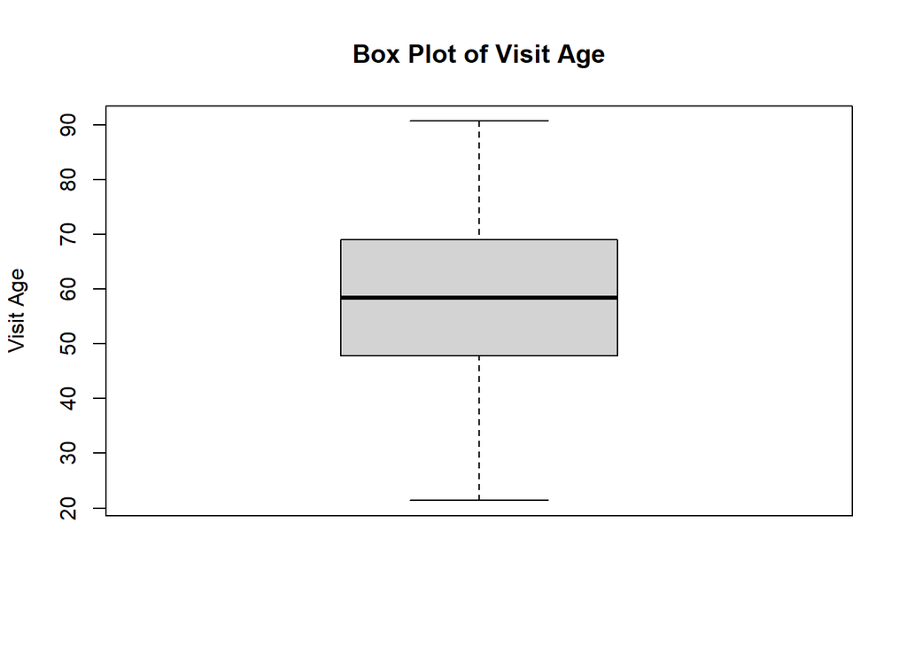

```r
# Categorize Numbiologicals
df_reg_i$Numbiologicals <- as.factor(df_reg_i$Numbiologicals)

# Categorize RF
df_reg_i$RF <- factor(df_reg_i$RF, levels = c(0, 1), labels = c("Negative", "Positive"))

# Categorize BMI
df_reg_i$BMI_Category <- cut(df_reg_i$BMI,
                             breaks = c(-Inf, 18.5, 24.9, 29.9, Inf),
                             labels = c("Underweight", "Normal weight", "Overweight", "Obesity"))

# Categorize DAS28 based on the threshold
df_reg_i$DAS28_Category <- ifelse(df_reg_i$DAS28 < 2.6, "Remission", "Active")

# Convert the new categories to factors
df_reg_i$DAS28_Category <- factor(df_reg_i$DAS28_Category, levels = c("Remission", "Active"))

boxplot(df_reg_i$Visit_Age, main = "Box Plot of Visit Age", ylab = "Visit Age")
```

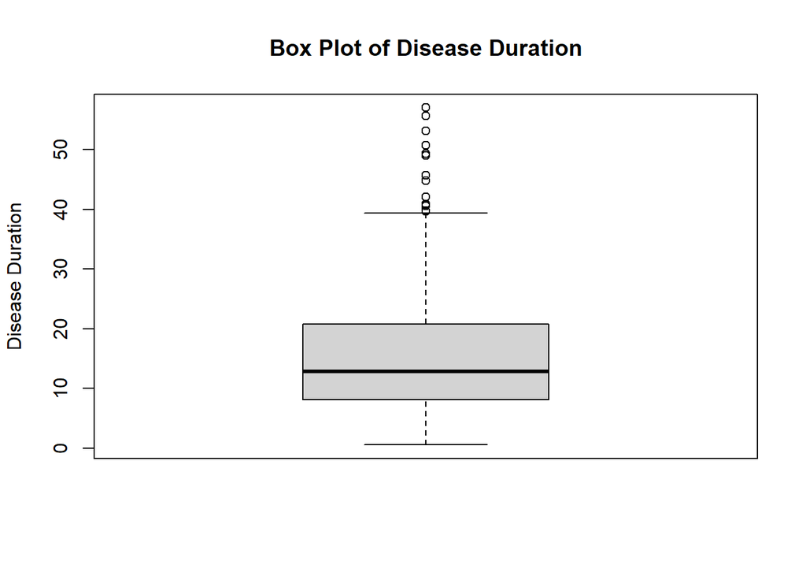

```r
boxplot(df_reg_i$Disease_Duration, main = "Box Plot of Disease Duration", ylab = "Disease Duration")
```

```r
median(df_reg_i$Visit_Age)
```

```
## [1] 58.46
```

```r
median(df_reg_i$Disease_Duration)
```

```
## [1] 12.81
```

```r
# Categorize Visit Age and Disease Duration based on their medians.

# Categorize Visit_Age based on the median value
df_reg_i$Visit_Age_Category <- ifelse(df_reg_i$Visit_Age <= 58.46, "Less or Equal to 58.46", "Greater than 58.46")

# Categorize Disease_Duration based on the median value
df_reg_i$Disease_Duration_Category <- ifelse(df_reg_i$Disease_Duration <= 12.81, "Less or Equal to 12.81", "Greater than 12.81")

# Convert the new categories to factors
df_reg_i$Visit_Age_Category <- factor(df_reg_i$Visit_Age_Category, levels = c("Less or Equal to 58.46", "Greater than 58.46"))

df_reg_i$Disease_Duration_Category <- factor(df_reg_i$Disease_Duration_Category, levels = c("Less or Equal to 12.81", "Greater than 12.81"))

# Standardize NUmeric Columns
numeric_cols <- sapply(df_reg_i, is.numeric)
df_reg_i[numeric_cols] <- scale(df_reg_i[numeric_cols])

str(df_reg_i)
```

```
## 'data.frame':    365 obs. of  27 variables:
##  $ Water_g                  : num  -0.8124 1.7811 -0.679 -0.4403 0.0948 ...
##  $ Alcohol_g                : num  0.869 -0.534 0.129 -0.537 0.121 ...
##  $ Energy_kcal              : num  -0.0396 0.4854 -0.3551 -0.3468 -0.4584 ...
##  $ Visit_Age                : num  -1.176 -1.399 -1.192 -0.493 0.708 ...
##  $ Disease_Duration         : num  -0.732 -0.365 -0.641 1.272 -0.225 ...
##  $ Sex                      : Factor w/ 2 levels "Femmina","Maschio": 2 1 1 1 1 1 1 1 1 2 ...
##  $ Education                : Factor w/ 4 levels "elementari","medie",..: 3 4 2 3 4 3 1 2 3 2 ...
##  $ BMI                      : num  0.451 -0.609 -0.939 0.181 1.464 ...
##  $ RF                       : Factor w/ 2 levels "Negative","Positive": 2 1 2 1 2 1 1 1 1 1 ...
##  $ GH_PATIENT               : num  0.262 1.278 1.024 -1.515 0.77 ...
##  $ GERD                     : Factor w/ 2 levels "FALSO","VERO": 1 1 1 2 1 1 2 1 1 2 ...
##  $ Gastritis                : Factor w/ 2 levels "FALSO","VERO": 1 1 1 1 1 1 1 1 1 1 ...
##  $ Hypertension             : Factor w/ 2 levels "FALSO","VERO": 1 1 1 1 1 1 2 1 1 2 ...
##  $ DM                       : Factor w/ 2 levels "FALSO","VERO": 1 1 1 1 1 1 1 1 1 1 ...
##  $ Cardiopathy              : Factor w/ 2 levels "FALSO","VERO": 1 1 1 1 1 1 1 1 1 1 ...
##  $ TP_CLASSIFICATION        : Factor w/ 5 levels "COMBO_cs/b","JAKi",..: 1 4 5 5 5 1 3 1 5 1 ...
##  $ Numbiologicals           : Factor w/ 7 levels "0","1","2","3",..: 2 2 2 1 1 2 1 1 3 2 ...
##  $ Smoker                   : Factor w/ 3 levels "Ex-fumatore",..: 2 3 3 1 1 1 3 3 3 2 ...
##  $ Animals                  : Factor w/ 2 levels "FALSO","VERO": 1 1 1 1 1 1 1 1 1 1 ...
##  $ DAS28                    : num  1.071909 -0.598511 0.000489 0.599799 0.295419 ...
##  $ present_drugs            : Factor w/ 2 levels "FALSE","TRUE": 2 1 2 2 2 2 2 2 2 2 ...
##  $ past_drugs               : Factor w/ 2 levels "FALSE","TRUE": 2 2 2 2 2 2 2 2 2 2 ...
##  $ any_disinfectant         : Factor w/ 2 levels "FALSE","TRUE": 1 2 1 1 1 1 1 1 1 1 ...
##  $ BMI_Category             : Factor w/ 4 levels "Underweight",..: 3 2 2 3 4 2 2 3 2 4 ...
##  $ DAS28_Category           : Factor w/ 2 levels "Remission","Active": 2 1 1 2 2 1 2 1 2 2 ...
##  $ Visit_Age_Category       : Factor w/ 2 levels "Less or Equal to 58.46",..: 1 1 1 1 2 1 2 1 1 1 ...
##  $ Disease_Duration_Category: Factor w/ 2 levels "Less or Equal to 12.81",..: 1 1 1 2 2 1 2 2 2 1 ...
```

```r
i_df <- c("Water_g", "Alcohol_g", "Energy_kcal", "Visit_Age_Category", "Disease_Duration_Category", "Sex",
  "Education", "BMI_Category", "RF", "GH_PATIENT", "GERD", "Gastritis",
  "Hypertension", "DM", "Cardiopathy", "TP_CLASSIFICATION", "Numbiologicals",
  "Smoker", "Animals", "DAS28_Category", "present_drugs", "past_drugs",
  "any_disinfectant")

df_mod <- df_reg_i[,i_df]

df_mod <- cbind(data[,1],df_mod) #Reintroducing the User code for easy access and lookup of data and combination with factorial analysis of food groups.
df_mod <- na.omit(df_mod)

patient_id <- df_mod[,1] # Separating out user codes to use later on

reg_df <- cbind(patient_id,df_mod) # to use only for combination with Facorial analysis later (not used anywhere else.)

df_mod <- df_mod[,-1]

summary(df_mod)
```

```
##     Water_g            Alcohol_g         Energy_kcal
##  Min.   :-1.625064   Min.   :-0.62699   Min.   :-2.06470
##  1st Qu.:-0.625202   1st Qu.:-0.62699   1st Qu.:-0.67187
##  Median :-0.169068   Median :-0.46749   Median :-0.10264
##  Mean   : 0.004696   Mean   :-0.00641   Mean   : 0.01981
##  3rd Qu.: 0.346121   3rd Qu.: 0.20404   3rd Qu.: 0.51236
##  Max.   : 6.982543   Max.   : 4.56503   Max.   : 4.97959
##
##               Visit_Age_Category          Disease_Duration_Category
##  Less or Equal to 58.46:177      Less or Equal to 12.81:174
##  Greater than 58.46    :169      Greater than 12.81    :172
##
##
##
##
##
##       Sex           Education          BMI_Category        RF
##  Femmina:273   elementari: 49   Underweight  : 23   Negative:160
##  Maschio: 73   medie     : 79   Normal weight:189   Positive:186
##                superiori :132   Overweight   : 94
##                università: 86   Obesity      : 40
##
##
##
##    GH_PATIENT           GERD     Gastritis   Hypertension     DM
##  Min.   :-3.546520   FALSO:279   FALSO:317   FALSO:231    FALSO:328
##  1st Qu.:-0.499490   VERO : 67   VERO : 29   VERO :115    VERO : 18
##  Median : 0.008348
##  Mean   :-0.020273
##  3rd Qu.: 0.770105
##  Max.   : 1.531863
##
##  Cardiopathy  TP_CLASSIFICATION Numbiologicals          Smoker     Animals
##  FALSO:329   COMBO_cs/b: 92     0:233          Ex-fumatore :108   FALSO:307
##  VERO : 17   JAKi      :  7     1: 61          Fumatore    : 54   VERO : 39
##              mono_b    : 76     2: 27          Non fumatore:184
##              no_tp     : 29     3: 13
##              only_cs   :142     4:  7
##                                 5:  3
##                                 6:  2
##    DAS28_Category present_drugs past_drugs  any_disinfectant
##  Remission:212    FALSE: 11     FALSE: 86   FALSE:274
##  Active   :134    TRUE :335     TRUE :260   TRUE : 72
##
##
##
##
##
```

```r
names(df_mod)
```

```
##  [1] "Water_g"                   "Alcohol_g"
##  [3] "Energy_kcal"               "Visit_Age_Category"
##  [5] "Disease_Duration_Category" "Sex"
##  [7] "Education"                 "BMI_Category"
##  [9] "RF"                        "GH_PATIENT"
## [11] "GERD"                      "Gastritis"
## [13] "Hypertension"              "DM"
## [15] "Cardiopathy"               "TP_CLASSIFICATION"
## [17] "Numbiologicals"            "Smoker"
## [19] "Animals"                   "DAS28_Category"
## [21] "present_drugs"             "past_drugs"
## [23] "any_disinfectant"
```

```r
str(df_mod)
```

```
## 'data.frame':    346 obs. of  23 variables:
##  $ Water_g                  : num  -0.8124 1.7811 -0.679 -0.4403 0.0948 ...
##  $ Alcohol_g                : num  0.869 -0.534 0.129 -0.537 0.121 ...
##  $ Energy_kcal              : num  -0.0396 0.4854 -0.3551 -0.3468 -0.4584 ...
##  $ Visit_Age_Category       : Factor w/ 2 levels "Less or Equal to 58.46",..: 1 1 1 1 2 1 2 1 1 1 ...
##  $ Disease_Duration_Category: Factor w/ 2 levels "Less or Equal to 12.81",..: 1 1 1 2 2 1 2 2 2 1 ...
##  $ Sex                      : Factor w/ 2 levels "Femmina","Maschio": 2 1 1 1 1 1 1 1 1 2 ...
##  $ Education                : Factor w/ 4 levels "elementari","medie",..: 3 4 2 3 4 3 1 2 3 2 ...
##  $ BMI_Category             : Factor w/ 4 levels "Underweight",..: 3 2 2 3 4 2 2 3 2 4 ...
##  $ RF                       : Factor w/ 2 levels "Negative","Positive": 2 1 2 1 2 1 1 1 1 1 ...
##  $ GH_PATIENT               : num  0.262 1.278 1.024 -1.515 0.77 ...
##  $ GERD                     : Factor w/ 2 levels "FALSO","VERO": 1 1 1 2 1 1 2 1 1 2 ...
##  $ Gastritis                : Factor w/ 2 levels "FALSO","VERO": 1 1 1 1 1 1 1 1 1 1 ...
##  $ Hypertension             : Factor w/ 2 levels "FALSO","VERO": 1 1 1 1 1 1 2 1 1 2 ...
##  $ DM                       : Factor w/ 2 levels "FALSO","VERO": 1 1 1 1 1 1 1 1 1 1 ...
##  $ Cardiopathy              : Factor w/ 2 levels "FALSO","VERO": 1 1 1 1 1 1 1 1 1 1 ...
##  $ TP_CLASSIFICATION        : Factor w/ 5 levels "COMBO_cs/b","JAKi",..: 1 4 5 5 5 1 3 1 5 1 ...
##  $ Numbiologicals           : Factor w/ 7 levels "0","1","2","3",..: 2 2 2 1 1 2 1 1 3 2 ...
##  $ Smoker                   : Factor w/ 3 levels "Ex-fumatore",..: 2 3 3 1 1 1 3 3 3 2 ...
##  $ Animals                  : Factor w/ 2 levels "FALSO","VERO": 1 1 1 1 1 1 1 1 1 1 ...
##  $ DAS28_Category           : Factor w/ 2 levels "Remission","Active": 2 1 1 2 2 1 2 1 2 2 ...
##  $ present_drugs            : Factor w/ 2 levels "FALSE","TRUE": 2 1 2 2 2 2 2 2 2 2 ...
##  $ past_drugs               : Factor w/ 2 levels "FALSE","TRUE": 2 2 2 2 2 2 2 2 2 2 ...
##  $ any_disinfectant         : Factor w/ 2 levels "FALSE","TRUE": 1 2 1 1 1 1 1 1 1 1 ...
```

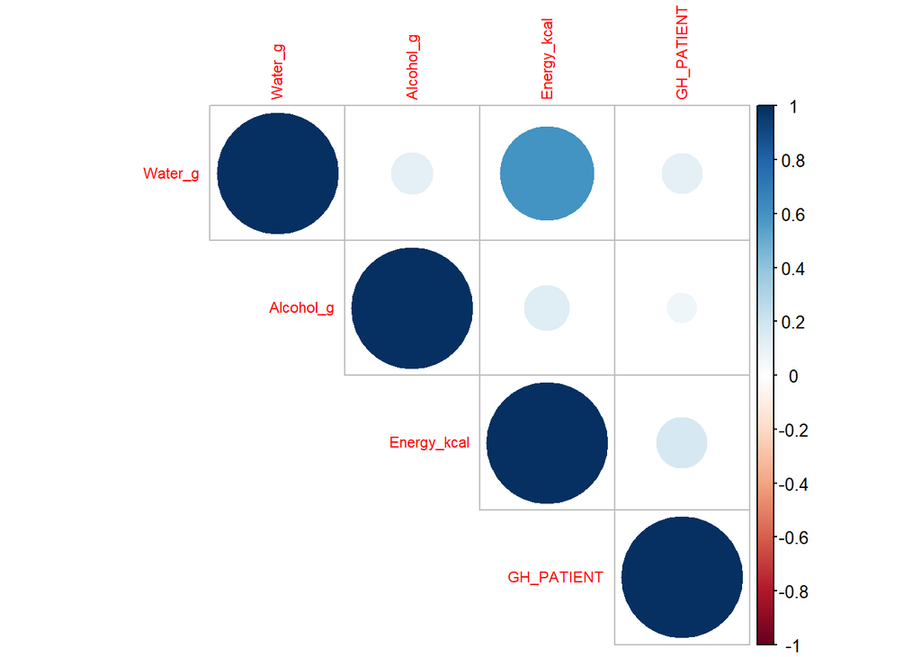

```r
numerical_cols <- sapply(df_mod, is.numeric)
df_numeric <- df_mod[, numerical_cols]

# Compute correlation matrix
correlation_matrix <- cor(df_numeric)

# Plot correlation matrix
library(corrplot)
corrplot(correlation_matrix, method = "circle", type = "upper", tl.cex = 0.7)
```

```r
model_das28 <- glm(DAS28_Category ~ . -Animals -RF -Cardiopathy -Alcohol_g -Gastritis -Numbiologicals -GH_PATIENT
                              +      Smoker * Hypertension
                              , data = df_mod, family = binomial(link = "logit"))

summary(model_das28)
```

```
##
## Call:
## glm(formula = DAS28_Category ~ . - Animals - RF - Cardiopathy -
##     Alcohol_g - Gastritis - Numbiologicals - GH_PATIENT + Smoker *
##     Hypertension, family = binomial(link = "logit"), data = df_mod)
##
## Coefficients:
##                                             Estimate Std. Error z value
## (Intercept)                                 -2.29036    1.23799  -1.850
## Water_g                                      0.02519    0.15053   0.167
## Energy_kcal                                 -0.26450    0.15989  -1.654
## Visit_Age_CategoryGreater than 58.46        -0.42640    0.29938  -1.424
## Disease_Duration_CategoryGreater than 12.81  0.49327    0.25940   1.902
## SexMaschio                                  -0.24276    0.32939  -0.737
## Educationmedie                              -0.66851    0.42518  -1.572
## Educationsuperiori                          -0.45163    0.41356  -1.092
## Educationuniversità                         -0.76030    0.44994  -1.690
## BMI_CategoryNormal weight                   -0.39401    0.50977  -0.773
## BMI_CategoryOverweight                      -0.17302    0.54472  -0.318
## BMI_CategoryObesity                          0.28414    0.60140   0.472
## GERDVERO                                     0.36711    0.31260   1.174
## HypertensionVERO                            -1.55767    0.49940  -3.119
## DMVERO                                       0.32607    0.60318   0.541
## TP_CLASSIFICATIONJAKi                        1.26198    0.91525   1.379
## TP_CLASSIFICATIONmono_b                     -0.45717    0.35936  -1.272
## TP_CLASSIFICATIONno_tp                       0.96468    0.56523   1.707
## TP_CLASSIFICATIONonly_cs                     0.52810    0.31975   1.652
## SmokerFumatore                               0.11378    0.43517   0.261
## SmokerNon fumatore                          -0.82786    0.35557  -2.328
## present_drugsTRUE                            2.20459    0.98114   2.247
## past_drugsTRUE                               0.66509    0.33057   2.012
## any_disinfectantTRUE                         0.64380    0.31415   2.049
## HypertensionVERO:SmokerFumatore              1.62151    0.89983   1.802
## HypertensionVERO:SmokerNon fumatore          1.84564    0.60351   3.058
##                                             Pr(>|z|)
## (Intercept)                                  0.06430 .
## Water_g                                      0.86709
## Energy_kcal                                  0.09807 .
## Visit_Age_CategoryGreater than 58.46         0.15437
## Disease_Duration_CategoryGreater than 12.81  0.05723 .
```

[output cut: 16 more lines]

```
## present_drugsTRUE                            0.02464 *
## past_drugsTRUE                               0.04422 *
## any_disinfectantTRUE                         0.04043 *
## HypertensionVERO:SmokerFumatore              0.07154 .
## HypertensionVERO:SmokerNon fumatore          0.00223 **
## ---
## Signif. codes:  0 '***' 0.001 '**' 0.01 '*' 0.05 '.' 0.1 ' ' 1
##
## (Dispersion parameter for binomial family taken to be 1)
##
##     Null deviance: 461.92  on 345  degrees of freedom
## Residual deviance: 409.50  on 320  degrees of freedom
## AIC: 461.5
##
## Number of Fisher Scoring iterations: 4
```

## LOGISTIC REGRESSION FOR DAS28 ON CONFOUNDERS

```r
data_scaled_with_factor_cores <- cbind(data[,1],data_scaled, factor_scores)

str(data_scaled_with_factor_cores)
```

```
## 'data.frame':    365 obs. of  50 variables:
##  $ code                    : num  8010002 8010003 8010005 8010007 8010008 ...
##  $ vf_redmeat              : num  0.5604 0.0735 0.4853 0.4125 -0.8138 ...
##  $ vf_whitemeat            : num  -0.705 0.303 0.303 0.303 -0.705 ...
##  $ vf_fish                 : num  -0.6608 -0.4962 1.5105 -0.0949 -0.3315 ...
##  $ vf_fat_fish             : num  -0.501 0.713 3.424 0.212 1.587 ...
##  $ vf_seafood              : num  0.333 -0.108 -0.536 -0.536 -0.108 ...
##  $ vf_eggs                 : num  -0.623 -0.224 -0.224 -0.224 0.872 ...
##  $ vf_sweets               : num  -0.226 0.464 -0.867 0.348 -0.409 ...
##  $ vf_snacks               : num  1.274 -0.282 2.643 -0.282 -0.435 ...
##  $ vf_dried_fruit          : num  -0.1142 0.0204 -0.1142 -0.1142 -0.1142 ...
##  $ vf_nuts                 : num  -0.4835 -0.4549 -0.3663 0.0632 -0.5408 ...
##  $ vf_olive_oil            : num  0.604 -0.547 -0.934 0.675 1.384 ...
##  $ vf_seed_oil             : num  -0.581 -0.581 3.472 -0.581 -0.581 ...
##  $ vf_vegetables           : num  -0.8768 -0.2745 0.0113 -0.4811 -0.047 ...
```

[output cut: 36 more lines]

```r
str(reg_df)
```

```
## 'data.frame':    346 obs. of  25 variables:
##  $ patient_id               : num  8010002 8010003 8010005 8010007 8010008 ...
##  $ code                     : num  8010002 8010003 8010005 8010007 8010008 ...
##  $ Water_g                  : num  -0.8124 1.7811 -0.679 -0.4403 0.0948 ...
##  $ Alcohol_g                : num  0.869 -0.534 0.129 -0.537 0.121 ...
##  $ Energy_kcal              : num  -0.0396 0.4854 -0.3551 -0.3468 -0.4584 ...
##  $ Visit_Age_Category       : Factor w/ 2 levels "Less or Equal to 58.46",..: 1 1 1 1 2 1 2 1 1 1 ...
##  $ Disease_Duration_Category: Factor w/ 2 levels "Less or Equal to 12.81",..: 1 1 1 2 2 1 2 2 2 1 ...
##  $ Sex                      : Factor w/ 2 levels "Femmina","Maschio": 2 1 1 1 1 1 1 1 1 2 ...
##  $ Education                : Factor w/ 4 levels "elementari","medie",..: 3 4 2 3 4 3 1 2 3 2 ...
##  $ BMI_Category             : Factor w/ 4 levels "Underweight",..: 3 2 2 3 4 2 2 3 2 4 ...
##  $ RF                       : Factor w/ 2 levels "Negative","Positive": 2 1 2 1 2 1 1 1 1 1 ...
##  $ GH_PATIENT               : num  0.262 1.278 1.024 -1.515 0.77 ...
##  $ GERD                     : Factor w/ 2 levels "FALSO","VERO": 1 1 1 2 1 1 2 1 1 2 ...
##  $ Gastritis                : Factor w/ 2 levels "FALSO","VERO": 1 1 1 1 1 1 1 1 1 1 ...
##  $ Hypertension             : Factor w/ 2 levels "FALSO","VERO": 1 1 1 1 1 1 2 1 1 2 ...
##  $ DM                       : Factor w/ 2 levels "FALSO","VERO": 1 1 1 1 1 1 1 1 1 1 ...
##  $ Cardiopathy              : Factor w/ 2 levels "FALSO","VERO": 1 1 1 1 1 1 1 1 1 1 ...
##  $ TP_CLASSIFICATION        : Factor w/ 5 levels "COMBO_cs/b","JAKi",..: 1 4 5 5 5 1 3 1 5 1 ...
##  $ Numbiologicals           : Factor w/ 7 levels "0","1","2","3",..: 2 2 2 1 1 2 1 1 3 2 ...
##  $ Smoker                   : Factor w/ 3 levels "Ex-fumatore",..: 2 3 3 1 1 1 3 3 3 2 ...
##  $ Animals                  : Factor w/ 2 levels "FALSO","VERO": 1 1 1 1 1 1 1 1 1 1 ...
##  $ DAS28_Category           : Factor w/ 2 levels "Remission","Active": 2 1 1 2 2 1 2 1 2 2 ...
##  $ present_drugs            : Factor w/ 2 levels "FALSE","TRUE": 2 1 2 2 2 2 2 2 2 2 ...
##  $ past_drugs               : Factor w/ 2 levels "FALSE","TRUE": 2 2 2 2 2 2 2 2 2 2 ...
##  $ any_disinfectant         : Factor w/ 2 levels "FALSE","TRUE": 1 2 1 1 1 1 1 1 1 1 ...
```

```r
# Combining both into a single df

merged_df_foodgrp_reg <- merge(data_scaled_with_factor_cores, reg_df, by.x = "code", by.y = "patient_id", all = TRUE)

str(merged_df_foodgrp_reg)
```

```
## 'data.frame':    365 obs. of  74 variables:
##  $ code                     : num  8010002 8010003 8010005 8010007 8010008 ...
##  $ vf_redmeat               : num  0.5604 0.0735 0.4853 0.4125 -0.8138 ...
##  $ vf_whitemeat             : num  -0.705 0.303 0.303 0.303 -0.705 ...
##  $ vf_fish                  : num  -0.6608 -0.4962 1.5105 -0.0949 -0.3315 ...
##  $ vf_fat_fish              : num  -0.501 0.713 3.424 0.212 1.587 ...
##  $ vf_seafood               : num  0.333 -0.108 -0.536 -0.536 -0.108 ...
##  $ vf_eggs                  : num  -0.623 -0.224 -0.224 -0.224 0.872 ...
##  $ vf_sweets                : num  -0.226 0.464 -0.867 0.348 -0.409 ...
##  $ vf_snacks                : num  1.274 -0.282 2.643 -0.282 -0.435 ...
##  $ vf_dried_fruit           : num  -0.1142 0.0204 -0.1142 -0.1142 -0.1142 ...
##  $ vf_nuts                  : num  -0.4835 -0.4549 -0.3663 0.0632 -0.5408 ...
##  $ vf_olive_oil             : num  0.604 -0.547 -0.934 0.675 1.384 ...
##  $ vf_seed_oil              : num  -0.581 -0.581 3.472 -0.581 -0.581 ...
##  $ vf_vegetables            : num  -0.8768 -0.2745 0.0113 -0.4811 -0.047 ...
```

[output cut: 60 more lines]

```r
names(merged_df_foodgrp_reg)
```

```
##  [1] "code"                      "vf_redmeat"
##  [3] "vf_whitemeat"              "vf_fish"
##  [5] "vf_fat_fish"               "vf_seafood"
##  [7] "vf_eggs"                   "vf_sweets"
##  [9] "vf_snacks"                 "vf_dried_fruit"
## [11] "vf_nuts"                   "vf_olive_oil"
## [13] "vf_seed_oil"               "vf_vegetables"
## [15] "vf_leafy_vegetables"       "vf_cabbages"
## [17] "vf_legumes"                "vf_onion_garlic"
## [19] "vf_mushrooms"              "vf_soy_products"
## [21] "vf_fruits_allseasons"      "vf_winter_fruits"
## [23] "vf_summer_fruits"          "vf_unsweetened_beverages"
## [25] "vf_coffee"                 "vf_alcoholic_beverages"
## [27] "vf_soft_drinks"            "vf_refined_grains"
## [29] "vf_potatoes"               "vf_whole_grains"
```

[output cut: 22 more lines]

```r
final_fg_cov_df <- merged_df_foodgrp_reg[,c(1,35:74)]

str(final_fg_cov_df)
```

```
## 'data.frame':    365 obs. of  41 variables:
##  $ code                     : num  8010002 8010003 8010005 8010007 8010008 ...
##  $ Factor1                  : num  -0.444 -0.389 0.285 -0.161 -0.306 ...
##  $ Factor2                  : num  -0.58 3.806 -1.512 -1.034 0.394 ...
##  $ Factor3                  : num  0.154 0.317 0.488 0.106 -0.159 ...
##  $ Factor4                  : num  0.363 -0.479 1.581 -0.941 -0.466 ...
##  $ Factor5                  : num  -0.369 -0.669 -1.133 0.27 -0.301 ...
##  $ Factor6                  : num  0.537 -0.27 -1.219 0.704 -0.433 ...
##  $ Factor7                  : num  0.129 -0.268 -0.58 0.186 -0.613 ...
##  $ Factor8                  : num  -0.814 -0.4845 -0.2628 0.0129 -0.525 ...
##  $ Factor9                  : num  0.484 -0.626 2.247 0.365 1.841 ...
##  $ Factor10                 : num  -0.8465 -0.4974 -0.0832 0.0243 -0.0291 ...
##  $ Factor11                 : num  0.11905 0.08446 -0.71269 1.01211 -0.00488 ...
##  $ Factor12                 : num  -1.095 -1.1361 1.149 1.1845 -0.0734 ...
##  $ Factor13                 : num  -0.0465 0.1533 0.369 -0.4976 -0.3469 ...
```

[output cut: 27 more lines]

## APPLYING 16 DIFFERENT REGRESSIONS FOR THE FOOD GROUPS, TAKING 1 INTO ACCOUNT AT ONCE WITH THE LOGISTIC REGRESSION

```r
# List of factors derived from factor analysis
factors <- paste0("Factor", 1:16)

# Prepare the base formula for logistic regression
formula_base <- "DAS28_Category ~ "

# Iterate over each factor
for (factor in factors) {
  # Construct the specific formula for each iteration
  formula <- paste(formula_base, factor)

  # Fit the logistic regression model
  model <- glm(formula, data = final_fg_cov_df, family = binomial(link = "logit"))

  # Print the summary of the model
  cat("\n\nLogistic Regression Summary for", factor, ":\n")
  print(summary(model))
}
```

```
##
##
## Logistic Regression Summary for Factor1 :
##
## Call:
## glm(formula = formula, family = binomial(link = "logit"), data = final_fg_cov_df)
##
## Coefficients:
##             Estimate Std. Error z value Pr(>|z|)
## (Intercept) -0.45895    0.11038  -4.158 3.21e-05 ***
## Factor1      0.01672    0.10681   0.157    0.876
## ---
## Signif. codes:  0 '***' 0.001 '**' 0.01 '*' 0.05 '.' 0.1 ' ' 1
##
## (Dispersion parameter for binomial family taken to be 1)
##
##     Null deviance: 461.92  on 345  degrees of freedom
## Residual deviance: 461.90  on 344  degrees of freedom
##   (19 observations deleted due to missingness)
## AIC: 465.9
##
## Number of Fisher Scoring iterations: 4
##
##
##
## Logistic Regression Summary for Factor2 :
##
## Call:
## glm(formula = formula, family = binomial(link = "logit"), data = final_fg_cov_df)
##
## Coefficients:
##             Estimate Std. Error z value Pr(>|z|)
## (Intercept) -0.45940    0.11050  -4.158 3.22e-05 ***
## Factor2     -0.09485    0.11304  -0.839    0.401
## ---
## Signif. codes:  0 '***' 0.001 '**' 0.01 '*' 0.05 '.' 0.1 ' ' 1
##
## (Dispersion parameter for binomial family taken to be 1)
##
##     Null deviance: 461.92  on 345  degrees of freedom
```

[output cut: 312 more lines]

```
## Coefficients:
##             Estimate Std. Error z value Pr(>|z|)
## (Intercept)  -0.4699     0.1115  -4.214 2.51e-05 ***
## Factor16     -0.2530     0.1215  -2.082   0.0373 *
## ---
## Signif. codes:  0 '***' 0.001 '**' 0.01 '*' 0.05 '.' 0.1 ' ' 1
##
## (Dispersion parameter for binomial family taken to be 1)
##
##     Null deviance: 461.92  on 345  degrees of freedom
## Residual deviance: 457.26  on 344  degrees of freedom
##   (19 observations deleted due to missingness)
## AIC: 461.26
##
## Number of Fisher Scoring iterations: 4
```

## APPLYING LOGISTIC REGRESSION BY CONSIDERING CONFOUNDERS AND 1 FACTOR AT A TIME

```r
# Prepare the base formula for logistic regression
formula_base1 <- "DAS28_Category ~ Energy_kcal + Disease_Duration_Category + Education + Hypertension + TP_CLASSIFICATION + Numbiologicals + Smoker + present_drugs +
                 past_drugs + any_disinfectant"

# Iterate over each factor
for (factor in factors) {
  # Construct the specific formula for each iteration
  formula <- paste(formula_base1, "+", factor)

  # Fit the logistic regression model
  model2 <- glm(formula, data = final_fg_cov_df, family = binomial(link = "logit"))

  # Print the summary of the model
  cat("\n\nLogistic Regression Summary for", factor, ":\n")
  print(summary(model2))
}
```

```
##
##
## Logistic Regression Summary for Factor1 :
##
## Call:
## glm(formula = formula, family = binomial(link = "logit"), data = final_fg_cov_df)
##
## Coefficients:
##                                               Estimate Std. Error z value
## (Intercept)                                 -2.869e+00  1.116e+00  -2.571
## Energy_kcal                                 -1.643e-01  1.249e-01  -1.315
## Disease_Duration_CategoryGreater than 12.81  5.113e-01  2.557e-01   2.000
## Educationmedie                              -5.213e-01  4.021e-01  -1.297
## Educationsuperiori                          -2.796e-01  3.682e-01  -0.759
## Educationuniversità                         -6.632e-01  4.049e-01  -1.638
## HypertensionVERO                            -4.210e-01  2.713e-01  -1.552
## TP_CLASSIFICATIONJAKi                        5.795e-01  1.012e+00   0.573
## TP_CLASSIFICATIONmono_b                     -3.532e-01  3.606e-01  -0.980
## TP_CLASSIFICATIONno_tp                       9.450e-01  5.629e-01   1.679
## TP_CLASSIFICATIONonly_cs                     6.866e-01  3.208e-01   2.140
## Numbiologicals1                              3.963e-01  3.446e-01   1.150
## Numbiologicals2                              4.137e-01  4.661e-01   0.887
## Numbiologicals3                              1.404e+00  6.735e-01   2.085
## Numbiologicals4                              1.019e+00  8.529e-01   1.195
## Numbiologicals5                             -7.311e-01  1.356e+00  -0.539
## Numbiologicals6                              1.456e+01  6.154e+02   0.024
## SmokerFumatore                               6.375e-01  3.762e-01   1.694
## SmokerNon fumatore                          -8.299e-02  2.751e-01  -0.302
## present_drugsTRUE                            1.780e+00  9.485e-01   1.877
## past_drugsTRUE                               3.566e-01  3.270e-01   1.091
## any_disinfectantTRUE                         5.509e-01  2.945e-01   1.871
## Factor1                                     -8.837e-04  1.205e-01  -0.007
##                                             Pr(>|z|)
## (Intercept)                                   0.0101 *
## Energy_kcal                                   0.1884
## Disease_Duration_CategoryGreater than 12.81   0.0455 *
## Educationmedie                                0.1947
## Educationsuperiori                            0.4477
## Educationuniversità                           0.1015
## HypertensionVERO                              0.1207
```

[output cut: 1032 more lines]

```
## present_drugsTRUE                             0.0537 .
## past_drugsTRUE                                0.2332
## any_disinfectantTRUE                          0.0637 .
## Factor16                                      0.0151 *
## ---
## Signif. codes:  0 '***' 0.001 '**' 0.01 '*' 0.05 '.' 0.1 ' ' 1
##
## (Dispersion parameter for binomial family taken to be 1)
##
##     Null deviance: 461.92  on 345  degrees of freedom
## Residual deviance: 412.03  on 323  degrees of freedom
##   (19 observations deleted due to missingness)
## AIC: 458.03
##
## Number of Fisher Scoring iterations: 13
```

```r
# Fitting a regression model on all factors taking into account, and the confounders

full_model_conf_factor <- glm(paste(formula_base1,"+",paste(factors, collapse = " + ")), data = final_fg_cov_df, family = binomial(link = "logit"))

summary(full_model_conf_factor)
```

```
##
## Call:
## glm(formula = paste(formula_base1, "+", paste(factors, collapse = " + ")),
##     family = binomial(link = "logit"), data = final_fg_cov_df)
##
## Coefficients:
##                                               Estimate Std. Error z value
## (Intercept)                                  -2.521875   1.154867  -2.184
## Energy_kcal                                  -0.039409   0.492016  -0.080
## Disease_Duration_CategoryGreater than 12.81   0.480725   0.274193   1.753
## Educationmedie                               -0.791149   0.437455  -1.809
## Educationsuperiori                           -0.464190   0.405012  -1.146
## Educationuniversità                          -0.884961   0.446826  -1.981
## HypertensionVERO                             -0.344837   0.287358  -1.200
## TP_CLASSIFICATIONJAKi                         0.913075   1.118353   0.816
## TP_CLASSIFICATIONmono_b                      -0.272981   0.378302  -0.722
## TP_CLASSIFICATIONno_tp                        0.906330   0.576317   1.573
## TP_CLASSIFICATIONonly_cs                      0.736766   0.337573   2.183
## Numbiologicals1                               0.276833   0.366265   0.756
## Numbiologicals2                               0.349476   0.477610   0.732
## Numbiologicals3                               1.381662   0.700508   1.972
## Numbiologicals4                               0.831835   0.912378   0.912
## Numbiologicals5                              -0.845780   1.429804  -0.592
## Numbiologicals6                              14.060039 623.153276   0.023
## SmokerFumatore                                0.576272   0.401572   1.435
## SmokerNon fumatore                           -0.188761   0.294426  -0.641
## present_drugsTRUE                             1.633759   0.976321   1.673
## past_drugsTRUE                                0.339810   0.343856   0.988
## any_disinfectantTRUE                          0.555214   0.310323   1.789
## Factor1                                       0.005133   0.150313   0.034
## Factor2                                      -0.078531   0.232017  -0.338
## Factor3                                       0.183513   0.209830   0.875
## Factor4                                      -0.202137   0.225121  -0.898
## Factor5                                      -0.002775   0.193506  -0.014
## Factor6                                      -0.029664   0.317373  -0.093
## Factor7                                      -0.019250   0.190504  -0.101
## Factor8                                      -0.128102   0.144612  -0.886
## Factor9                                      -0.207411   0.177920  -1.166
## Factor10                                      0.108395   0.133361   0.813
## Factor11                                     -0.393139   0.254950  -1.542
```

[output cut: 40 more lines]

```
## Factor13                                      0.5522
## Factor14                                      0.1602
## Factor15                                      0.5219
## Factor16                                      0.0239 *
## ---
## Signif. codes:  0 '***' 0.001 '**' 0.01 '*' 0.05 '.' 0.1 ' ' 1
##
## (Dispersion parameter for binomial family taken to be 1)
##
##     Null deviance: 461.92  on 345  degrees of freedom
## Residual deviance: 397.68  on 308  degrees of freedom
##   (19 observations deleted due to missingness)
## AIC: 473.68
##
## Number of Fisher Scoring iterations: 13
```